## Construction of a prediction model

## Introduction

The goal of this exercise is to predict how well a physical activity (in this case barbell lifts) is performed by a test person, given data from accelerometers attached to the subjects arm, forearm, belt and barbell. The data for this analysis were obtained from [http://groupware.les.inf.puc-rio.br/har]  
The variable to be predicted is named *classe* and consists of 5 levels describing how well the exercise was performed. The levels range from *A* to *E*, from exactly following the specifications through various errors made during the execution. Refer the link in the above for more information.

The analysis was done on a dual core 2.0GHz processor, 2GB internal RAM, using R version 3.0.2 on a 64-bit Linux distribution (Ubuntu 13.04).

## Acquiring the data

The training data and test data sets were respectively obtained from:  
- Training set: [here](https://d396qusza40orc.cloudfront.net/predmachlearn/pml-training.csv)  
- Test set: [here](https://d396qusza40orc.cloudfront.net/predmachlearn/pml-testing.csv)

Loading the data into R:

```r
training <- read.csv("../data/pml-training.csv")
testing <- read.csv("../data/pml-testing.csv")
```

## Exploratory analysis and pre-processing the data

Both the raw training data and the test data contain 160 predictor variables, the training data have 19622 observations and the test data have 20 observations to be used for predictions.

Removing impertinent columns and columns with missing data

```r
##remove empty and NA columns from data set
no_na <- sapply(training, function(x) all(!is.na(x)))
train_pp <-training[no_na]
not_empty <- sapply(train_pp, function(x) all(x != ""))
train_pp <- train_pp[not_empty]

#remove user_name, cvtd_timestamp and new_window columns, i.e. non sensor data
#and column magnet_belt_z which does not exist in test set
train_pp <- train_pp[,-c(1:6, 20)]
```

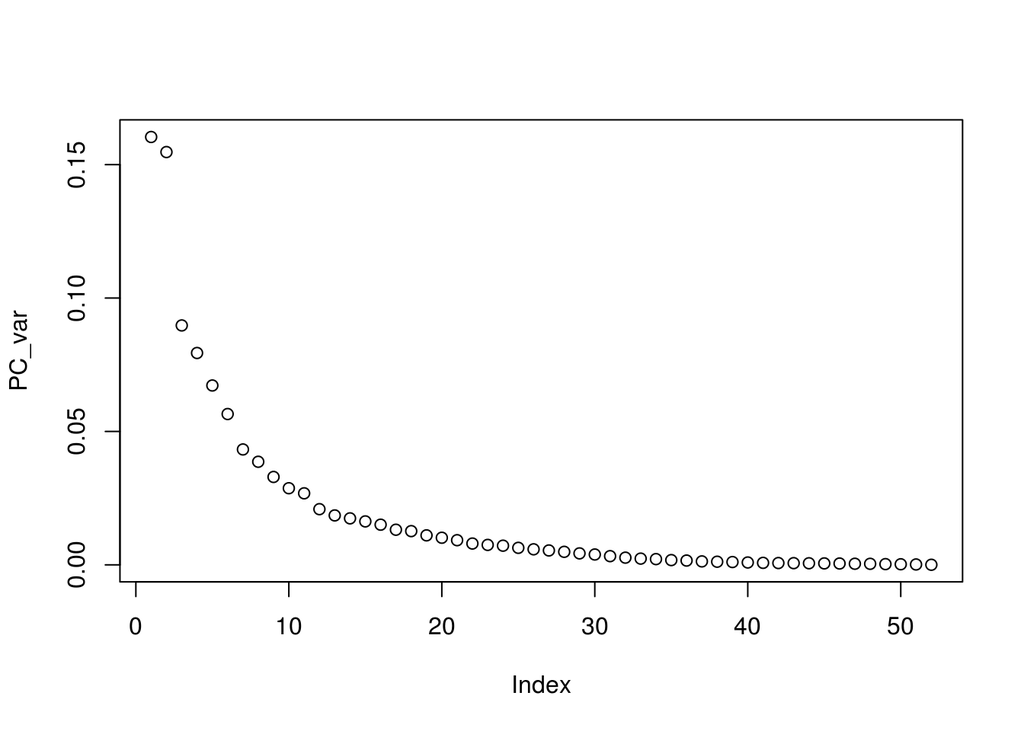

```r
### principal component analysis
pc_a <- prcomp(train_pp[-53], center=TRUE, scale=TRUE)
PC_var <- pc_a$sd^2/sum(pc_a$sd^2)
plot(PC_var)
```

Plotting these two features against each other, shows that the outcomes are grouped into 5 clusters, but unfortunately the outcomes are distributed randomly:

```r
### first two components seem significant, plot clusters:
require(ggplot2)
```

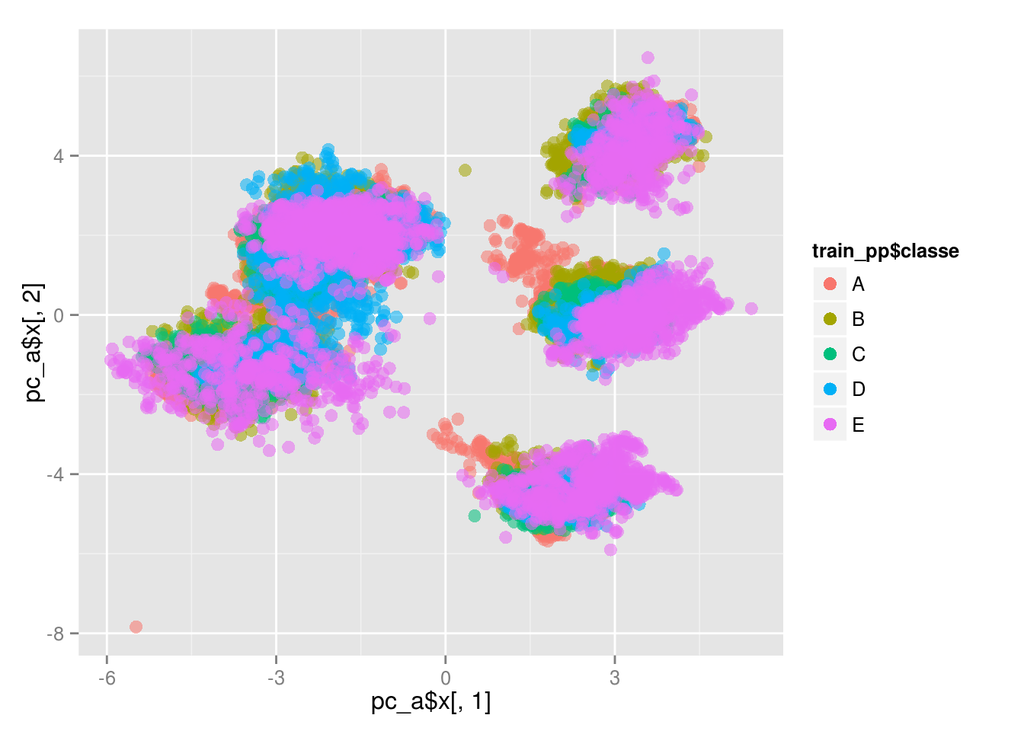

```r
ggplot(data=NULL, aes(x=pc_a$x[,1], y=pc_a$x[,2], color=train_pp$classe)) +
  geom_point(size=3,alpha=0.55)+ guides(colour = guide_legend(override.aes = list(alpha = 1)))
```

Subsequently the training data are divided into a training and validation set in a 70%/30% proportion:

```r
require(caret)
set.seed(23)
in_train <- createDataPartition(y=train_pp$classe, p=0.70, list=FALSE)
validation <- train_pp[-in_train,]
train_pp <- train_pp[in_train,]
```

It is possible to check the correlation between predictors, and it follows that many predictors are actually highly correlated (> 0.80, dark blue):

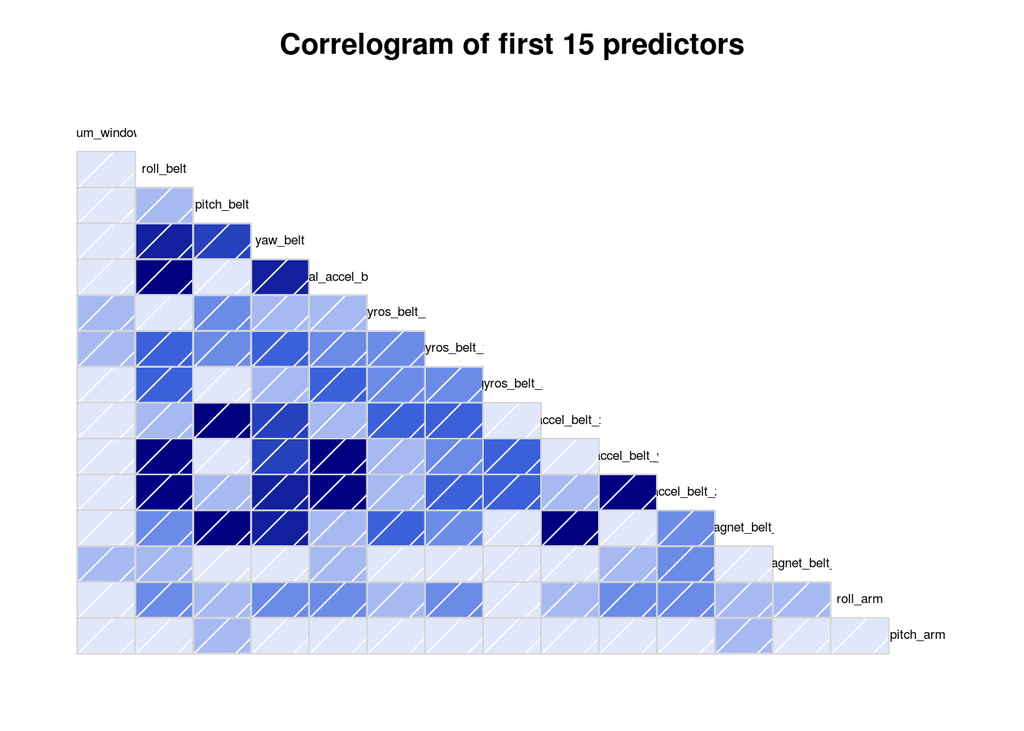

```r
M <- abs(cor(train_pp[,-53]))
diag(M) <- 0
require(corrgram)
corrgram(M[1:15,1:15], main="Correlogram of first 15 predictors", upper.panel=NULL)
```

Because the number of predictors is relative small, and resulting from the above analysis of the predictor variance, I decided to not do any pre-processing of the data in terms of selecting a subset of relevant predictors in addition to the earlier steps taken.

## Model fitting

Now that the pre-processing of the data is done, the next step in the analysis is model fitting. I decided to fit 3 predictive models to the data, namely:  
- A simple Classification and Regression Tree model  
- A Support Vector Machine model  
- A Random Forest model with a 4-fold re-sampling cross validation

Before we can start the model fitting, make sure that we can make use of both available CPUs for parallel computing:

```r
#construct a trainControl object to allow for parallel processing
require(doMC)
registerDoMC(2)  #allow for multicore calcs
```

Fit the models:

```r
##regression tree model
tr_control <- trainControl(allowParallel = TRUE)
model_rpart <- train(train_pp$classe ~ ., trControl=tr_control, method="rpart", data=train_pp)
##support vector machine model
model_svm <- svm(train_pp$classe ~ ., data=train_pp)
##random forest with 4 fold resampling
tr_control <- trainControl(method="cv", number=4, allowParallel=TRUE)
model_rf <- train(train_pp$classe ~ ., trControl=tr_control, method="rf", data=train_pp)
```

Using these models on the validation set yields:

```r
pred_rpart <- predict(model_rpart, validation)
pred_svm <- predict(model_svm, validation)
pred_rf <- predict(model_rf, validation)
```

The resulting out-of-sample accuracy for each of the methods is:  
- CART: 0.5222  
- SVM: 0.9456  
- RF: 0.9985

It is possible to compute a confusion matrix showing the results of the predictive model while using the validation data set. In this case, only the confusion matrix for the random forest model is shown.

```r
validation$pred_right <- pred_rf == validation$classe
confusionMatrix(pred_rf, validation$classe)
```

```
## Confusion Matrix and Statistics
##
##           Reference
## Prediction    A    B    C    D    E
##          A 1673    5    0    0    0
##          B    1 1134    0    0    0
##          C    0    0 1026    1    0
##          D    0    0    0  963    2
##          E    0    0    0    0 1080
##
## Overall Statistics
##
##                Accuracy : 0.998
##                  95% CI : (0.997, 0.999)
##     No Information Rate : 0.284
##     P-Value [Acc > NIR] : <2e-16
##
##                   Kappa : 0.998
##  Mcnemar's Test P-Value : NA
##
## Statistics by Class:
##
##                      Class: A Class: B Class: C Class: D Class: E
## Sensitivity             0.999    0.996    1.000    0.999    0.998
## Specificity             0.999    1.000    1.000    1.000    1.000
## Pos Pred Value          0.997    0.999    0.999    0.998    1.000
## Neg Pred Value          1.000    0.999    1.000    1.000    1.000
## Prevalence              0.284    0.194    0.174    0.164    0.184
## Detection Rate          0.284    0.193    0.174    0.164    0.184
## Detection Prevalence    0.285    0.193    0.175    0.164    0.184
## Balanced Accuracy       0.999    0.998    1.000    0.999    0.999
```

The out of sample accuracy is highest when the random forest model is used. Use this model on the test data, after the same pre-processing steps are taken as applicable to the training data.

```r
#make sure that the test set contains the same columns as the training set
no_na <- sapply(testing, function(x) all(!is.na(x)))
test_pp <-testing[no_na]
not_empty <- sapply(test_pp, function(x) all(x != ""))
test_pp <- test_pp[not_empty]
#remove user_name, cvtd_timestamp and new_window columns, i.e. non sensor data
test_pp <- test_pp[,-c(1:6,20)]
```

Now it is possible to predict the *classe* outcome using the variables in the test set, and output the result:

```r
test_rf <- predict(model_rf, test_pp)
test_rf
```

```
##  [1] B A B A A E D B A A B C B A E E A B B B
## Levels: A B C D E
```

This model correctly predicts the outcome of 20 out of 20 observations in the test set.

## Recommendations

There are a couple of things that can be investigated in addition to the analysis done here. First of all, it is possible to decrease the number of observations in the training set by about 75%. The out of sample accuracy suffers somewhat, but this is offset by a large improvement in the time needed to fit the random forest model.  
In addition, it would be very interesting to experiment with additional prediction models and model stacking/combining several models.